# Sensor fundamentals

We learn a great deal about image quality and noise limits by counting the (**Poisson**) arrival of photons at each pixel and measuring the responses to gratings. Because ISET uses physical units throughout, we can calculate the number of incident photons, or stored electrons, at each pixel in the sensor. We can then look more broadly across the optics-sensor and ask how well the sensor encodes images at different spatial frequencies (MTF).

## Contents

- Standard initialization
- Measure the variation in sensor electrons (shot noise)
- Experiments with spatial resolution
- List of parameters
- Create an optical image with some default optics.
- Create a monochrome image sensor array
- Compute the MTF as we change the pixel size
- Plot all the mtfData
- Show a visual example of the effect of pixel size
- The IP window
- Show the Poisson distribution and its noise characteristics
- Explore how pixel size impacts the sensor resolution.
- Create an MTF graph to analyze the resolution

**See also:**

s_sensorSNR, s_sensorStackedPixels

## Standard initialization

```matlab
ieInit;
```

## Measure the variation in sensor electrons (shot noise)

We start with a low intensity uniform scene with equal energy at every wavelength. 10 is pretty dark. But you can experiment by changing the the number of candelas below and rerunning this section.

```matlab
uscene  = sceneCreate('uniform equal energy');
candelas = 10;                         % Units are cd/m^2
uscene  = sceneAdjustLuminance(uscene,candelas);
uscene  = sceneSet(uscene,'fov',10); % The scene extends a 10 degree field of view
%
uscene = sceneAdjustIlluminant(uscene,'D65.mat')
% sceneWindow(uscene);
```

```
uscene =

  struct with fields:

          type: 'scene'
      metadata: []
          name: 'uniform-equal energy'
      spectrum: [1×1 struct]
    illuminant: [1×1 struct]
          data: [1×1 struct]
      distance: 1.2000
      wAngular: 10
```

Calculate the optical image for a diffraction limited optics. This represents the irradiance that arrives at the sensor after passing through the optics.

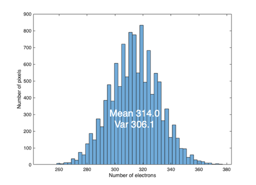

```matlab
oi = oiCreate('diffraction limited');
oi = oiSet(oi,'optics off axis method','skip');   % We won't add any vignetting to the optics
oi = oiCompute(oi,uscene); % Pass the scene through the optics

% oiWindow(oi);
% A monochrome sensor with a field of view that is smaller than the scene

msensor = sensorCreate('monochrome');
msensor = sensorSetSizeToFOV(msensor,5,oi);

% Set the exposure duration to be short (1ms). You can experiment with this
% if you'd like.
msensor = sensorSet(msensor,'exp time',0.01);    % Units are in seconds

% Set the sensor to have no noise, quantization, or clipping
msensor = sensorSet(msensor,'noise flag',-1);  % No noise or quantization
msensor = sensorCompute(msensor,oi);

% Add photon noise.  Normally this happens within sensorCompute, but we are
% explicitly controlling it here in this tutorial.
msensor = sensorSet(msensor,'noise flag',1);   % Add only photon noise
msensor = sensorAddNoise(msensor);
% sensorWindow(msensor);
% A histogram of the electron count across the pixels.
% Given that the scene is uniform, and how we have controlled the noise, this
% produces the shot noise distribution (variation in electrons due to photon noise)

e = sensorGet(msensor,'electrons');
r = range(e(:));
nBins = min(r,50);  % Makes a nice plot

ieNewGraphWin;
h = histogram(e(:),nBins); % try "hist" for older versions of MATLAB
xlabel('Number of electrons');
ylabel('Number of pixels');
mn = double(mean(e(:)));
txt = sprintf('Mean %.1f\nVar %.1f',mn,var(e(:)));
text(mn,max(h.Values)/3,0,txt,'HorizontalAlignment','center','FontSize',20,'Color',[1 1 1])
```

## Experiments with spatial resolution

We consider the effect of pixel size on the sensor MTF in the following sections. Let's start fresh.

```matlab
ieInit
```

## List of parameters

The slanted bar scene is often used to assess spatial resolution. We can compute the modulation transfer function (MTF) from the sensor and image processing response to the slanted bar.

```matlab
dyeSizeMicrons = 512;            % Microns
clear psSize;                    % Pixel size (width)
pSize = [2 3 5 8];               % Different pixel sizes in microns

sceneBar = sceneCreate('slanted bar', 512);

% Let's set a few scene parameters.
sceneBar = sceneAdjustLuminance(sceneBar,10);    % Candelas/m2
sceneBar = sceneSet(sceneBar,'distance',1);      % Distance of the scene in meters
sceneBar = sceneSet(sceneBar,'fov',5);           % Field of view in degrees
% sceneWindow(sceneBar);
```

## Create an optical image with some default optics.

Now, compute the optical image from this scene and the current optical image properties

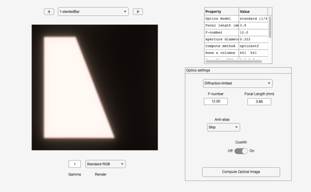

```matlab
oi = oiCreate('diffraction limited');
fNumber = 12;
oi = oiSet(oi,'optics fnumber',fNumber);

oi = oiCompute(oi,sceneBar);
oiWindow(oi);
```

## Create a monochrome image sensor array

```matlab
sensor = sensorCreate('monochrome');                %Initialize
sensor = sensorSet(sensor,'autoExposure',1); % Set to auto exposure
ip = ipCreate;
```

## Compute the MTF as we change the pixel size

We are now ready to set sensor and pixel parameters to produce a variety of captured images. Set the image processing properties for the monochrome imager. The default image processor does not sensor convert or illuminant balance, so it is appropriate.

```matlab
% Loop over different pixel sizes
mtfData = cell(1,length(pSize));
for ii=1:length(pSize)

    % Adjust the pixel size (meters) on the sensor
    sensor = sensorSet(sensor,'pixel size constant fill factor',[pSize(ii) pSize(ii)]*1e-6);

    %Adjust the sensor row and column size so that the sensor has a constant
    %field of view.
    sensor = sensorSetSizeToFOV(sensor,5,oi);
    sensor = sensorCompute(sensor,oi);
    ip = ipCompute(ip,sensor); % Image processing pipeline

    mtfData{ii} = ieISO12233(ip,sensor,'none');
end
```

```
No black border detected
No black border detected
No black border detected
No black border detected
```

## Plot all the mtfData

We compute the *mtfData* cell array contains all the information plotted in this figure. We graph the results, comparing the different pixel size MTFs.

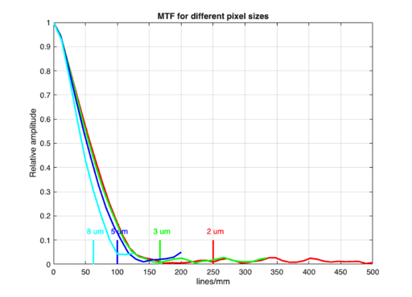

```matlab
ieNewGraphWin;
c = {'r','g','b','c','m','y','k'};
for ii=1:length(mtfData)
    h = plot(mtfData{ii}.freq,mtfData{ii}.mtf,['-',c{ii}],'LineWidth',2);
    hold on
    newText = sprintf('%.0f um\n',pSize(ii));
    nfreq = mtfData{ii}.nyquistf;
    l = line([nfreq ,nfreq],[0.1,0],'color',c{ii});
    l.LineWidth = 2;
    text((nfreq-10),0.12,newText,'color',c{ii});
end

xlabel('lines/mm'); ylabel('Relative amplitude');
title('MTF for different pixel sizes');
hold off; grid on
```

## Show a visual example of the effect of pixel size

We find it useful to look at images to understand what the changes in MTF means. Furthermore, using the whole calculation lets you notice other perceptual effects that are not obvious from one type of engineering metric. In this case, the color artifacts may seem surprising.

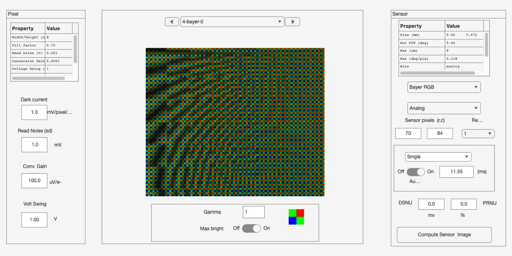

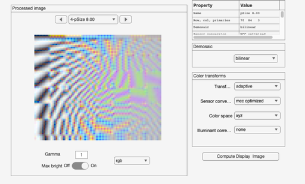

```matlab
sceneFO = sceneCreate('freq orient',512);
fov   = sceneGet(sceneFO,'fov');
oi    = oiCreate('diffraction limited');
oi    = oiCompute(oi,sceneFO);
ip    = ipCreate;

% Let's try it with an RGB sensor this time.
sensor = sensorCreate;

for ii=1:length(pSize)

    % Adjust the pixel size (meters)
    sensor = sensorSet(sensor,'pixel size constant fill factor',[pSize(ii) pSize(ii)]*1e-6);
    sensor = sensorSetSizeToFOV(sensor,fov,oi);
    sensor = sensorCompute(sensor,oi);
    sensorWindow(sensor);
    ip = ipCompute(ip,sensor);
    ip = ipSet(ip,'name',sprintf('pSize %.2f',pSize(ii)));
    ipWindow(ip);
end
```

## The IP window

You might think a bit about why undersampling with big pixels, and then interpolating the data into the final processed, leads to these large color artifacts.

[Published with MATLAB® R2025b](https://www.mathworks.com/products/matlab/)